# 7.2 Terrain analysis and visualization

*7.1 Map algebra* introduced calculations across raster cells and their neighborhoods. A digital elevation model contains elevation values, while terrain variables describe how elevation changes across neighboring cells. Those changes define slope, aspect, topographic position, and surface roughness.

In this lesson, we will calculate terrain variables with *terra*, combine elevation and hillshade in a map, draw that map on an interactive basemap with *tmap*, and render the elevation surface in three dimensions with *rayshader*.

In completing this lesson, you will learn how to:

- Calculate slope, aspect, and other terrain variables with `terrain()`
- Explain how raster resolution, CRS, and elevation units affect terrain calculations
- Build a hillshade with `shade()` and draw it
- Draw a raster in *tmap* with `tm_raster()`, and stack two raster layers on an interactive map
- Convert a `SpatRaster` into the matrix that *rayshader* works on
- Render a terrain surface in three dimensions

**Important!** Before starting this tutorial, be sure that you have completed all preliminary and previous lessons!

## Data for this lesson

**`scbi_dem.tif`**: Digital elevation model (raster) of the Smithsonian Conservation Biology Institute campus and the land around it, subset from a Virginia state elevation model. The file is in EPSG 4269, with cells of about three meters, and contains elevations in meters.

## Set up your session

Please complete the following to ensure that you are working in a clean session:

1. Please ensure that your **Global Environment** is empty.
2. In the *History* tab of your **workspace pane**, ensure that your **session history** is empty.

This lesson uses packages the course has not needed before:

```r
install.packages(
  c(
    "ggnewscale",
    "rayshader"
  )
)
```

Now that we are working in a clean session:

1. Create a script file.
2. Save your script file as `scripts/terrain.R`.
3. Add metadata as a comment on the top of the file.
4. Following your metadata, create a new **code section** and call it “`setup`”.
5. Following your section header, attach *tidyterra*, *rayshader*, *sf*, *tmap*, and the packages that comprise the **core tidyverse**, then load the module 3 source script and set the *tmap* mode to view.

At this point, your script should look something like:

```r
# My code for the terrain tutorial

# setup --------------------------------------------------------

library(tidyterra)
library(rayshader)
library(sf)
library(tmap)
library(tidyverse)

# Load the source script:

source("scripts/source_script_module_3.R")

# Draw interactive maps:

tmap_mode("view")
```

Create a code section called “`read and pre-process data`” and read the elevation model:

```r
dem <-
  terra::rast("data/raw/gis_scbi/scbi_dem.tif")

terra::res(dem)
```

```
[1] 3.08642e-05 3.08642e-05
```

The resolution is reported in degrees because this raster uses a geographic CRS. `terrain()` uses the CRS when calculating horizontal distances, and its elevation values must use meters. Calculate the terrain variables from the original elevation model rather than resampling it first.

## Slope and aspect

We can calculate terrain variables from an elevation raster with `terrain()`. `v =` identifies the variable, and `unit =` sets the units for slope and aspect:

```r
slope <-
  dem %>%
  terra::terrain(
    v = "slope",
    unit = "degrees"
  )
```

```
class       : SpatRaster
size        : 745, 778, 1  (nrow, ncol, nlyr)
resolution  : 3.08642e-05, 3.08642e-05  (x, y)
extent      : -78.17401, -78.15, 38.87901, 38.90201  (xmin, xmax, ymin, ymax)
coord. ref. : lon/lat NAD83 (EPSG:4269)
source(s)   : memory
varname     : scbi_dem
name        :     slope
min value   :         0
max value   : 57.688644
```

Each cell now contains the steepness of the surface at that location, in degrees from horizontal. The steepest cells occur along the creek bank.

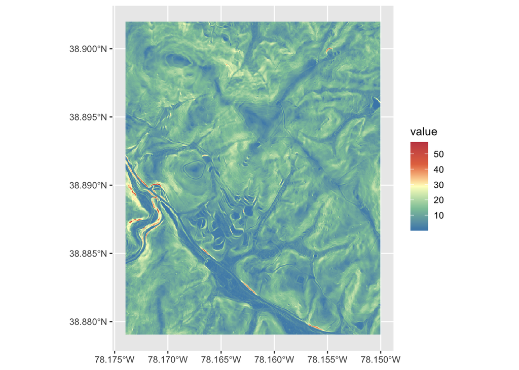

```r
ggplot() +

  # Add the raster layer:

  geom_spatraster(data = slope) +

  # Define the scale:

  scale_fill_whitebox_c(palette = "muted")
```

`v =` can identify several variables. `terrain()` returns a layer for each:

```r
terrain_layers <-
  dem %>%
  terra::terrain(
    v =
      c(
        "slope",
        "aspect",
        "TPI",
        "roughness"
      ),
    unit = "degrees"
  )

terrain_layers %>%
  terra::global(
    c(
      "mean",
      "min",
      "max"
    ),
    na.rm = TRUE
  )
```

```
                  mean           min        max
slope     1.117668e+01  2.274354e-14  57.688644
aspect    1.893066e+02  5.274880e-04 359.999497
TPI       3.198261e-04 -2.775520e+00   2.535295
roughness 1.564417e+00  0.000000e+00  11.456818
```

**`slope`** is the steepness of the surface.

**`aspect`** is the compass direction the surface faces, in degrees clockwise from north. In the northern hemisphere a south-facing slope receives more sun than a north-facing one, which is why aspect turns up in models of vegetation, snowpack and soil moisture in mountainous country.

**`TPI`**, the topographic position index, is the difference between a cell’s elevation and the mean of its neighbors. Positive values occur on ridges, negative values occur in valleys, and values near zero occur on uniform slopes.

**`roughness`** is the difference between the highest and lowest cells in a neighborhood. We calculated the same quantity with `focal()` in *7.1 Map algebra*. `terrain()` also supports the terrain ruggedness index (`"TRI"`) and flow direction (`"flowdir"`). Consult its help page when those variables are needed.

Never average an aspect!

The mean in the table above is the trap. Aspect is measured in degrees around a circle, and 1 degree and 359 degrees are two degrees apart on the ground and 358 apart in arithmetic. The mean of the two is 180, which is due south, and both slopes face north.

Every summary that treats aspect as a number on a line is wrong in the same way, and no amount of care with `na.rm` fixes it. The usual alternatives are:

- Classify aspect into compass sectors and count them, converting a circular quantity into a categorical variable.
- Transform aspect into linear components. `cos(aspect)` in radians returns northness, from 1 due north to -1 due south, and `sin(aspect)` returns eastness.

Northness is often useful in a model because it varies continuously with solar exposure.

Now you!

Return a raster of northness, and use it to report the mean slope of the north-facing ground and of the south-facing ground.

*Hint: Set `unit = "radians"` when calculating aspect. Its cosine is the northness described above. Everything after that is `ifel()` and `zonal()` from* **7.1 Map algebra***.*

Click here to see my answer

```r
northness <-
  dem %>%
  terra::terrain(
    v = "aspect",
    unit = "radians"
  ) %>%
  cos() %>%
  rename(northness = aspect)

facing <-
  terra::ifel(
    northness > 0,
    1,
    0
  ) %>%
  rename(facing = northness)

slope %>%
  terra::zonal(
    facing,
    fun = "mean",
    na.rm = TRUE
  )
```

```
  facing    slope
1      0 11.01108
2      1 11.34077
```

Zone 1 is the ground with a northerly component to its aspect and zone 0 is the rest. On this landscape the two are within a degree of each other, which is what a set of stream valleys running in several directions looks like.

Splitting at zero is the crudest version of the classification the box above describes. A study of solar exposure may require sectors rather than halves. `classify()` can build them from the aspect raster in degrees.

## Hillshade

A **hillshade** represents the illumination of a surface from a specified light position. Hillshade provides visual cues about terrain shape, while a color scale represents elevation values.

`shade()` takes slope and aspect **in radians**, the elevation angle of the light, and its compass direction:

```r
slope_radians <-
  dem %>%
  terra::terrain(
    v = "slope",
    unit = "radians"
  )

aspect_radians <-
  dem %>%
  terra::terrain(
    v = "aspect",
    unit = "radians"
  )

hillshade <-
  terra::shade(
    slope_radians,
    aspect_radians,
    angle = 45,
    direction = 315
  )
```

```
class       : SpatRaster
size        : 745, 778, 1  (nrow, ncol, nlyr)
resolution  : 3.08642e-05, 3.08642e-05  (x, y)
extent      : -78.17401, -78.15, 38.87901, 38.90201  (xmin, xmax, ymin, ymax)
coord. ref. : lon/lat NAD83 (EPSG:4269)
source(s)   : memory
varname     : scbi_dem
name        : hillshade
min value   : -0.137597
max value   :  0.998409
```

`direction = 315` puts the light in the northwest, which is the convention in cartography and has been since long before computers. A light from the southeast makes most readers see the valleys as ridges and the ridges as valleys, an illusion strong enough that it survives being pointed out.

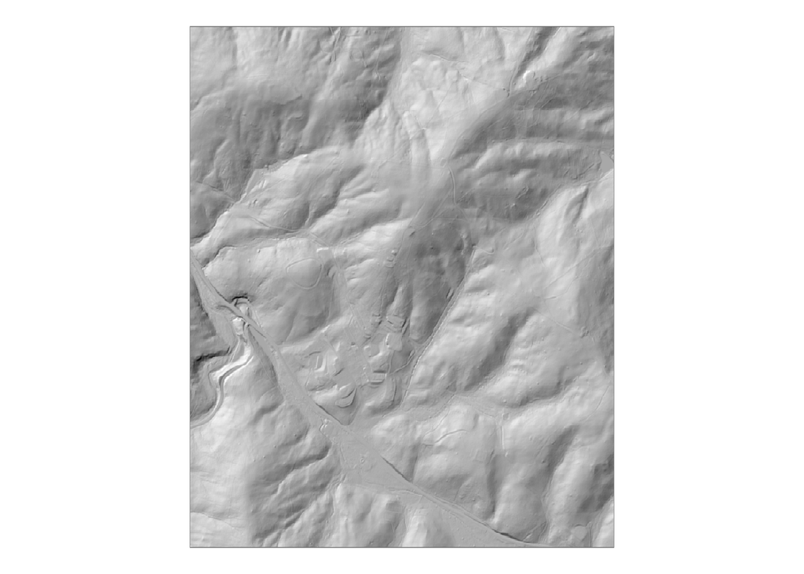

```r
ggplot() +

  # Add the hillshade:

  geom_spatraster(data = hillshade) +

  # Define the scale:

  scale_fill_gradient(
    low = "black",
    high = "white",
    guide = "none"
  ) +
  theme_void()
```

We can overlay a colored elevation layer on the hillshade. `ggnewscale::new_scale_fill()` begins a new fill scale between the hillshade and elevation layers:

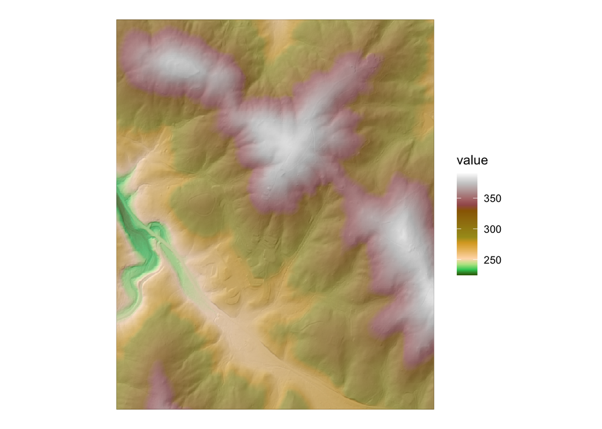

```r
ggplot() +

  # Add the hillshade:

  geom_spatraster(data = hillshade) +
  scale_fill_gradient(
    low = "black",
    high = "white",
    guide = "none"
  ) +

  # Begin a new fill scale:

  ggnewscale::new_scale_fill() +

  # Add elevation:

  geom_spatraster(
    data = dem,
    alpha = 0.6
  ) +
  scale_fill_hypso_c() +

  # Define the theme:

  theme_void()
```

## Rasters in tmap

Every raster in modules 6 and 7 has been drawn with `geom_spatraster()`. *tmap* draws rasters as well, and in view mode it places them on a basemap that a reader can pan and zoom (see *3.5 Introduction to tmap*). `tm_raster()` is the layer for a raster, in the position that `tm_polygons()` takes for a polygon layer.

A raster layer is styled through `col.scale =` and `col.legend =`, in the way that a polygon layer is styled through `fill.scale =` and `fill.legend =` (see *5.5 Cartography II: Projection, context, and labels*). `tm_scale_continuous()` maps the cell values onto the ramp given in `values =`, which takes the name of a palette or a vector of colors. Let’s draw the hillshade in grey over aerial imagery, and suppress its legend, because a reader has no use for an illumination value:

```r
tm_basemap("Esri.WorldImagery") +

  # Add the hillshade:

  tm_shape(
    hillshade,
    name = "Hillshade"
  ) +
  tm_raster(
    col.scale =
      tm_scale_continuous(
        values =
          gray.colors(
            n = 7,
            start = 0,
            end = 1
          )
      ),
    col_alpha = 0.5,
    col.legend = tm_legend(show = FALSE)
  )
```

[interactive chart not shown]

`tm_basemap()` chooses the tiles the map is drawn on, as it does for a map of vector features (see *3.5 Introduction to tmap*). A raster holds a value in every cell of its extent, so it hides the tiles beneath it unless we make it transparent: `col_alpha =` sets that transparency, and at 0.5 the imagery reads through the shading.

`name =` sets the label for the layer in the layer control of a view-mode map. A single layer needs no control, but the label is what a reader looks for once a second layer is drawn over the first.

A second raster is a second `tm_shape()` and a second `tm_raster()`. We draw elevation over the hillshade at a lower `col_alpha =`, so that both the relief and the imagery show through the colors:

```r
tm_basemap("Esri.WorldImagery") +

  # Add the hillshade:

  tm_shape(
    hillshade,
    name = "Hillshade"
  ) +
  tm_raster(
    col.scale =
      tm_scale_continuous(
        values =
          gray.colors(
            n = 7,
            start = 0,
            end = 1
          )
      ),
    col_alpha = 0.5,
    col.legend = tm_legend(show = FALSE)
  ) +

  # Add the elevation:

  tm_shape(
    dem,
    name = "Elevation"
  ) +
  tm_raster(
    col.scale =
      tm_scale_continuous(
        values =
          terrain.colors(n = 10)
      ),
    col_alpha = 0.4,
    col.legend =
      tm_legend(title = "Elevation (m)")
  )
```

[interactive chart not shown]

This is the map of the previous section with imagery beneath it and a layer control in the corner. Turn the elevation off and the hillshade alone remains, which is the quickest way to see what the shading contributes.

View mode draws in Web Mercator

View mode draws on web tiles, which are in Web Mercator, so *tmap* projects the raster before it draws. Large rasters are resampled on the way, and a categorical raster needs `col.scale = tm_scale_categorical()` so that its codes are not averaged.

Calculate on the raster in its own CRS, as we did above, and leave the reprojection to the map.

Now you!

Map the slope of the campus in view mode over aerial imagery, with a continuous color scale and a legend titled “Slope (degrees)”.

Click here to see my answer

```r
tm_basemap("Esri.WorldImagery") +

  # Add the slope:

  tm_shape(
    slope,
    name = "Slope"
  ) +
  tm_raster(
    col.scale =
      tm_scale_continuous(values = "brewer.yl_or_rd"),
    col_alpha = 0.6,
    col.legend =
      tm_legend(title = "Slope (degrees)")
  )
```

[interactive chart not shown]

## Rayshader

*rayshader* renders an elevation matrix as an image or a three-dimensional scene, and it builds that image in layers. Each function returns an array that the next one modifies, and `plot_map()` draws whatever the chain has produced. The walkthrough on the [*rayshader* website](https://www.rayshader.com/) adds one layer at a time to a stretch of the California coast. We will follow it on the campus.

`raster_to_matrix()` converts a `SpatRaster` into the matrix that *rayshader* works on, and we prepare the raster before converting it. `project()` moves the elevation model to NAD83 / UTM zone 17N so that horizontal distance and elevation both use meters. Projecting rotates the grid, which leaves no-data in the corners of the new rectangle, and `crop()` removes that margin: `terra::ext(dem_utm) - 100` is the extent of the raster pulled in by 100 meters on every side. `aggregate()` then combines blocks of two cells by two, because the shading functions trace a ray from every cell and their cost follows the cell count.

```r
dem_utm <-
  dem %>%
  terra::project("EPSG:26917")

elevation_matrix <-
  dem_utm %>%
  terra::crop(
    terra::ext(dem_utm) - 100
  ) %>%
  terra::aggregate(
    fact = 2,
    fun = "mean",
    na.rm = TRUE
  ) %>%
  raster_to_matrix()

dim(dem_utm)
```

```
[1] 855 707   1
```

```r
dim(elevation_matrix)
```

```
[1] 321 395
```

The row and column dimensions are reversed during the conversion. `raster_to_matrix()` performs that change in orientation.

Set `zscale` from the horizontal cell spacing and the vertical unit. *rayshader*’s documentation defines it as *“the ratio between the x and y spacing (which are assumed to be equal) and the z axis”*. The cells of `elevation_matrix` are about six meters apart and its elevations are in meters, which makes six the true ratio.

The campus rises 167 meters across about two kilometers, and at its true ratio that landscape renders nearly flat. Cartographers exaggerate the vertical scale to make gentle relief readable, and lowering `zscale` is how *rayshader* does it: `zscale = 0.4` renders this landscape with about fifteen times its real relief. **An exaggerated rendering belongs with a statement of the exaggeration, because a reader cannot recover it from the image.**

### Color from the surface

`sphere_shade()` colors each cell according to the direction its surface faces, using one of *rayshader*’s built-in textures: `imhof1` through `imhof4`, `desert`, `bw` and `unicorn`. `plot_map()` draws the array it returns:

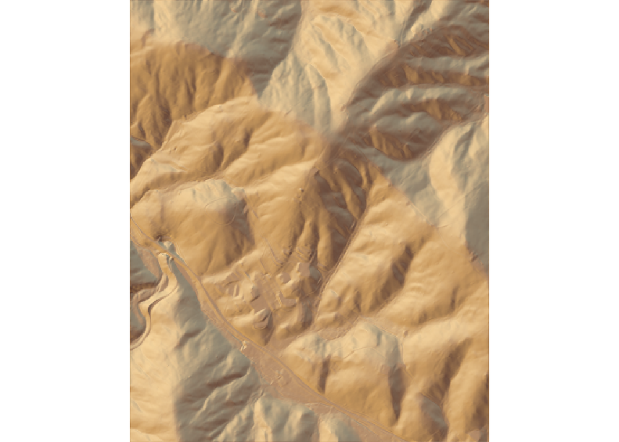

```r
elevation_matrix %>%
  sphere_shade(
    texture = "desert",
    zscale = 0.4
  ) %>%
  plot_map()
```

Nothing is in shadow. Every cell has the color assigned to its orientation, and the relief we can read comes from that coloring alone. The buildings of the campus and the road along the valley floor are in the elevation model, because it was built from lidar returns from everything present at the surface.

### Moving the light

`sunangle =` sets the bearing the highlight comes from, in degrees clockwise from north, and it defaults to 315. Let’s light the same surface from the northeast:

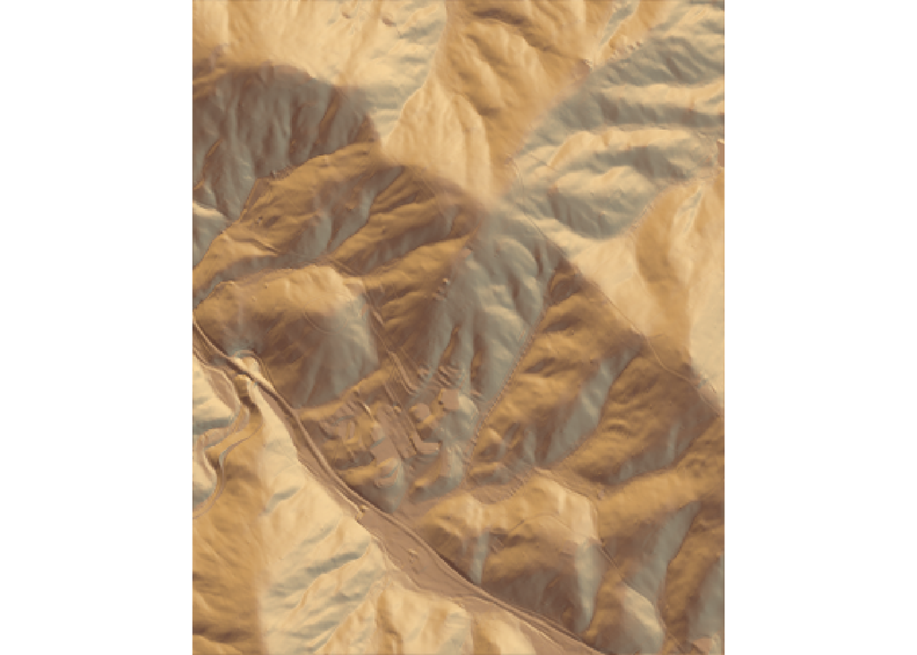

```r
elevation_matrix %>%
  sphere_shade(
    texture = "desert",
    zscale = 0.4,
    sunangle = 45
  ) %>%
  plot_map()
```

### Cast shadows

`ray_shade()` propagates a ray from every cell toward the light and darkens the cell for each ray that the surface blocks, which is what puts one hillside in the shadow of another. Its `sunaltitude =` is the angle above the horizon and its `sunangle =` the bearing, defaulting to 45 and 315. `add_shadow()` multiplies the colored array by a shadow map, and its `max_darken =` sets how dark a fully shadowed cell becomes, where 0 is black and 1 has no effect:

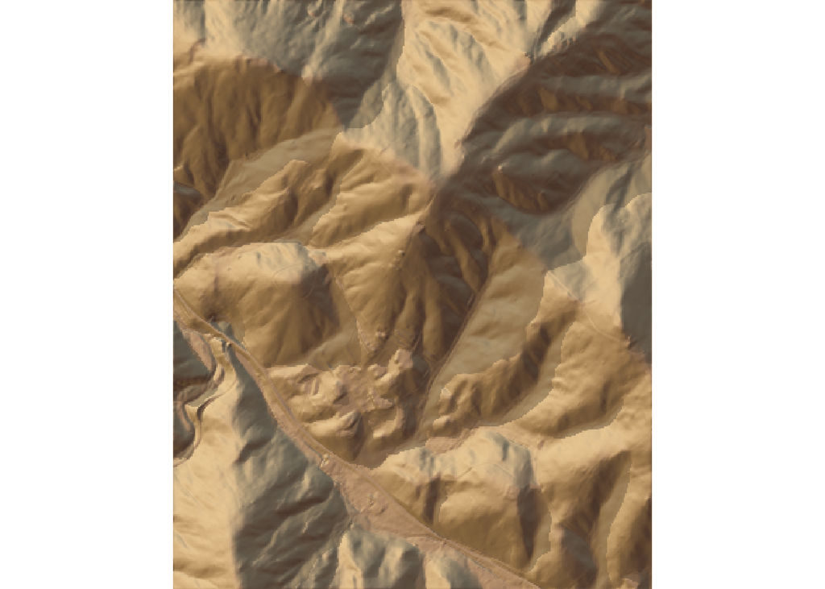

```r
elevation_matrix %>%
  sphere_shade(
    texture = "desert",
    zscale = 0.4
  ) %>%
  add_shadow(
    ray_shade(
      elevation_matrix,
      zscale = 0.4
    ),
    max_darken = 0.5
  ) %>%
  plot_map()
```

`ray_shade()` takes its own `zscale`, and it has to match the one given to `sphere_shade()`. The length of a shadow depends on the height of the terrain against its horizontal spacing, so a shadow map calculated at a different exaggeration lands in the wrong place.

### Ambient occlusion

`ambient_shade()` calculates the proportion of the sky visible from each cell. Valley cells have a narrow sky view and become darker, while ridge cells have a wider sky view and remain brighter. The calculation traces rays in many directions from every cell rather than toward a single light, which makes it the slowest step in the chain:

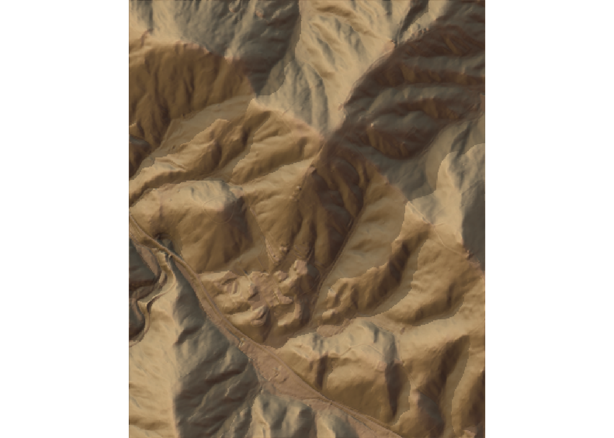

```r
elevation_matrix %>%
  sphere_shade(
    texture = "desert",
    zscale = 0.4
  ) %>%
  add_shadow(
    ray_shade(
      elevation_matrix,
      zscale = 0.4
    ),
    max_darken = 0.5
  ) %>%
  add_shadow(
    ambient_shade(
      elevation_matrix,
      zscale = 0.4
    ),
    max_darken = 0
  ) %>%
  plot_map()
```

Let’s look at the hollows between the ridges against the previous image. Ambient occlusion is what separates a surface that looks lit from a surface that looks solid.

### A three-dimensional scene

`plot_3d()` takes the place of `plot_map()` at the end of the chain. It uses the shaded array for color and the elevation matrix for height, and it opens a window rather than drawing an image. `theta =` rotates the scene, `phi =` raises the camera above the horizon, `zoom =` moves it closer, `fov =` sets the field of view, `windowsize =` gives the window its dimensions in pixels, and `soliddepth =` sets the elevation the base of the block is cut at.

The shaded array and the surface take their own `zscale`, and here we give them different values. The shading stays at `zscale = 0.4`, which is what gives the surface its texture. The height of the block runs at `zscale = 2.5`, about two and a half times the real relief, because a surface raised fifteen times reads as a mountain range rather than as the campus:

```r
elevation_matrix %>%
  sphere_shade(
    texture = "desert",
    zscale = 0.4
  ) %>%
  add_shadow(
    ray_shade(elevation_matrix, zscale = 0.4),
    max_darken = 0.5
  ) %>%
  add_shadow(
    ambient_shade(elevation_matrix, zscale = 0.4),
    max_darken = 0
  ) %>%
  plot_3d(
    elevation_matrix,
    zscale = 2.5,
    soliddepth = 210,
    fov = 0,
    theta = 315,
    phi = 32,
    zoom = 0.62,
    windowsize = c(1600, 1200),
    background = "white"
  )

render_snapshot()
```

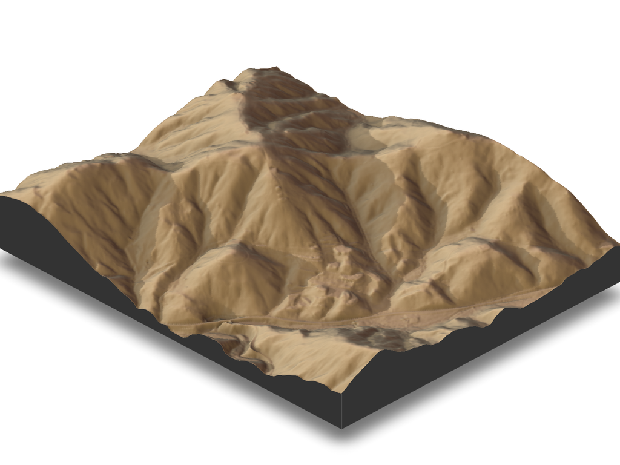

The scene opens in a window that can be rotated and zoomed with the mouse, and the image above is one view of it. `render_snapshot()` captures the current view and displays it, and a file name given to it writes the image to disk instead.

Rendering at full resolution

Raising `fact` in the `aggregate()` call renders faster and coarser. Dropping the call renders the elevation model at its own three-meter cells. Most of the execution time is spent in `ray_shade()` and `ambient_shade()`, especially `ambient_shade()`.

`zscale` moves with the cell spacing. A matrix of three-meter cells rendered at the exaggeration used here takes `zscale = 0.2` rather than `0.4`. The texture and the light position transfer unchanged.

A scene opened by `plot_3d()` stays open until `rgl::close3d()` closes it, and a second `plot_3d()` draws into the same window.

## Putting it all together

Terrain analysis starts with the original elevation model and then branches according to how the surface needs to be shown. My own model for that looks like this (click to expand):

[figure not shown]

**Note**

This workflow is a visualization of *my* mental model for these functions. It is totally okay if your model differs! What is important is that you have a *working* model, a system in place that allows you to retrieve the function or functions that you need to solve a problem.

## Take-home points

- `terrain()` uses a raster’s CRS to calculate distances. Calculate terrain variables from the original elevation model, with elevation values in meters and a known CRS, rather than projecting it first.
- `terrain()` returns slope, aspect, TPI, TRI, roughness, and flowdir, one layer per variable named in `v =`, with `unit =` setting degrees or radians.
- Aspect is circular, so its mean is meaningless. Take `cos()` of aspect in radians for a northness, or classify it into compass sectors.
- `shade()` builds a hillshade from slope and aspect **in radians**, with `angle =` for the elevation of the light and `direction =` for its bearing. A light from the northwest is the convention, and a light from the southeast inverts the relief for most readers.
- Use `ggnewscale::new_scale_fill()` to overlay a colored elevation layer on a hillshade with a separate fill scale.
- `tm_raster()` draws a raster in *tmap*, styled through `col.scale =` and `col.legend =`. A second `tm_shape()` stacks a layer over the first, and `col_alpha =` lets the layers beneath it show through.
- *rayshader* works on a matrix rather than a `SpatRaster`. `raster_to_matrix()` handles the conversion and orientation.
- `zscale` is the horizontal cell spacing divided by the vertical unit, so a raster of 10-meter cells containing elevations in meters takes `zscale = 10`. An incorrect value distorts the terrain.
- `ray_shade()` is expensive. Build the scene on an aggregated raster and change one line to run it at full resolution.

## Exercises

Test your knowledge!

1. Why does `shade()` need slope and aspect rather than elevation?

The brightness of a surface depends on the angle between it and the light, which slope and aspect describe Elevation is in the wrong units shade() cannot read a single-layer raster It uses elevation as well, supplied through the angle argument

2. A colleague reports the mean aspect of a study area as 181 degrees and concludes that it faces south. What is wrong?

Aspect is circular, so an arithmetic mean of it means nothing The mean should have been taken in radians Aspect is measured counterclockwise from east, so 181 is north Nothing, provided na.rm was set to TRUE

3. A raster contains elevation values in meters and has 10-meter cells. What `zscale` renders it at its true proportions?

10 1 0.1 It depends on the range of the elevations

## Reference

- **Code section**: A portion of an R script file that is delineated by a section header.
- **Global environment**: A workspace that provides a reference point for all user-assigned objects associated with the current session.
- **Hillshade**: A raster of how brightly each cell would be lit by a light source in a given position, used to show the shape of a surface.
- **Session history**: All lines of code that have been sent to R since the beginning of a session (or since the session history was last cleared).
- **Workspace pane**: A pane of RStudio used to view/manage objects in your global environment and your session history.

**Important!** Primitive functions, as well as functions in the packages that R attaches by default (e.g., *base*, *utils*, *stats*, and *graphics*), are available as soon as you start an R session.

| Package | Function | Definition |
| --- | --- | --- |
| .Primitive | + | Infix arithmetic operator (addition) |
| .Primitive | - | Infix arithmetic operator (subtract) or prefix negative symbol operator |
| .Primitive | / | Infix arithmetic operator (divide) |
| .Primitive | : | Infix operator that generates a regular sequence of adjacent values |
| .Primitive | :: | Infix operator that can be used to access a package environment without attaching the whole package environment to your current session |
| .Primitive | <- | Infix operator that assigns an object on the right-hand-side (RHS) to a name on the left-hand-side (LHS) -- this should be used for global assignments! |
| .Primitive | = | Infix operator that assigns an object on the right-hand-side (RHS) to a name on the left-hand-side (LHS) -- this should not be used for global assignments! |
| .Primitive | > | Infix relational operator (greater than) |
| .Primitive | c | Combine values to form an atomic vector |
| base | cos | Return the cosine of an angle given in radians. |
| base | dim | Return the dimensions (number of rows and columns, or array dimensions) of a data object. |
| base | library | Attach the package environment for a given package to the current R session |
| base | source | Execute a source script (in its entirety) |
| dplyr | rename | Change the name assigned to a column in a data frame |
| ggnewscale | new_scale_fill | Start a second fill scale in a ggplot, so that one plot can carry two. |
| ggplot2 | ggplot | Set the data and, potentially, the aesthetics of a plot |
| ggplot2 | scale_fill_gradient | A continuous fill scale running between two colors. |
| ggplot2 | theme_void | A ggplot theme that contains no axes or panel background |
| grDevices | gray.colors | Generate a color palette of gray colors |
| grDevices | terrain.colors | Generate a color palette of terrain colors |
| magrittr | %>% | The pipe operator passes the output of the LHS argument to the function on the right |
| rayshader | add_shadow | Combine a shaded image with a shadow map. |
| rayshader | ambient_shade | Return a map of the proportion of the sky visible from each cell of an elevation matrix |
| rayshader | plot_3d | Open a three-dimensional scene from a shaded image and the elevation matrix it was made from. |
| rayshader | plot_map | Draw a shaded image of an elevation matrix. |
| rayshader | raster_to_matrix | Convert a SpatRaster into the elevation matrix that rayshader works on |
| rayshader | ray_shade | Return a map of the shadows an elevation matrix casts from a light source in a given position. |
| rayshader | render_snapshot | Write the current three-dimensional scene to an image file. |
| rayshader | sphere_shade | Return a shaded image of an elevation matrix, colored by the direction each part of the surface faces. |
| terra | aggregate | Combine adjacent raster cells into larger cells by applying a summary function. |
| terra | crop | Subset a raster to a new spatial extent (e.g., a bounding box) |
| terra | ext | Return or set the extent of a terra object. |
| terra | global | Calculate a summary statistic across each cell in a raster |
| terra | ifel | Return a raster holding one value where a condition is TRUE and another where it is FALSE. |
| terra | project | Transform the CRS of a raster |
| terra | rast | Read in a raster object, create a raster object from scratch, or convert a list of raster objects to a raster stack |
| terra | res | Return or assign the resolution (cell size) of a raster. |
| terra | shade | Generate a hillshade raster |
| terra | terrain | Calculate the slope and aspect (and more!) for an elevation raster |
| terra | zonal | Summarize one raster within the classes of another raster on the same grid. |
| tidyterra | geom_spatraster | Draw a SpatRaster in a ggplot, mapping its first layer to fill unless another is named. |
| tidyterra | scale_fill_hypso_c | A continuous fill scale using a hypsometric palette, the convention for elevation on a topographic map. |
| tidyterra | scale_fill_whitebox_c | A continuous fill scale using one of the palettes of the WhiteboxTools software. |
| tmap | tm_basemap | Add a basemap layer to an interactive tmap |
| tmap | tm_legend | Configure a layer's legend (title, position, frame, orientation) in tmap v4. |
| tmap | tm_raster | Add a raster layer to a tmap |
| tmap | tm_scale_continuous | Define a continuous visual-variable scale for a tmap v4 layer. |
| tmap | tm_shape | Define the shape that is the source of a tmap layer |
| tmap | tmap_mode | Set a tmap to either "plot" (static map) or "view" (interactive map) |
| utils | install.packages | Download and install one or more packages onto your computer. |

The most common keyboard shortcuts are provided below for Windows and Mac operating systems.

| Task | Windows | Mac |
| --- | --- | --- |
| View all keyboard shortcuts | Alt + ⇧ + K | ⌥ + ⇧ + K |
| Open an existing script | Ctrl + O | ⌘ + O |
| Create a new script | Ctrl + ⇧ + N | ⌘ + ⇧ + N |
| Save script file | Ctrl + S | ⌘ + S |
| Execute code | Ctrl + Enter | ⌘ + Return |
| Copy | Ctrl + C | ⌘ + C |
| Paste | Ctrl + V | ⌘ + V |
| Add a pipe operator | Ctrl + ⇧ + M | ⌘ + ⇧ + M |
| Add an assignment operator | Alt + dash | ⌥ + dash |
| Add a new code section | Ctrl + ⇧ + R | ⌘ + ⇧ + R |
| Indent code | Ctrl + I | ⌘ + I |